# Checking BoneMarrowMap labels on SCPCP000007

JN Taroni

2026

## Introduction

BoneMarrowMap labeled every cell in the 26 AML libraries and the 2 healthy controls of SCPCP000007 (`09_predict-scpca-bonemarrowmap.R`). There’s no truth, so this notebook checks the labels against evidence BoneMarrowMap didn’t use:

- **Protein (ADT, 21 targets)**, the main independent check, especially of HSPC *state* (CD90, CD49f, CD45RA, CD133).
- **RNA marker genes** for each label.
- **ScPCA’s consensus labels.**
- **The healthy controls**, which should look like normal marrow.

It starts with a specific concern from the mapping run. In the KMT2A-rearranged library (SCPCL000343), 76% of cells were labeled orthochromatic erythroblast with high mapping error, while ScPCA’s consensus found no erythroid cells there. **Do off-reference or low-complexity cells default to late erythroblast labels?**

See `.workspace/annotate-aml/scpcp000007.md` (step 3) for the plan.

Conventions:

- **Mapping QC uses one threshold across the project** (2.5 MADs above the median of all cells; decision 3 in `bonemarrowmap.md`), not BoneMarrowMap’s per-library flag.
- **Pseudotime is set to NA for T, NK, plasma and stromal labels**, which sit outside the reference’s hierarchy (as in 06).
- **ADT “positive”** means above the 95th percentile of the same target in a population that shouldn’t express it, taken from the healthy controls (see “ADT positivity thresholds”). It’s a heuristic for summarizing, not a gate.

## Setup

```r
suppressPackageStartupMessages({
  library(dplyr)
  library(ggplot2)
})

root_dir <- rprojroot::find_root(rprojroot::has_dir(".git"))
module_dir <- fs::path(root_dir, "analyses", "annotate-aml")
scpca_results <- fs::path(module_dir, "results", "scpca")
bmm_file <- fs::path(scpca_results, "bonemarrowmap", "bonemarrowmap_predictions_SCPCP000007.tsv")
features_file <- fs::path(scpca_results, "features", "cell_features_SCPCP000007.tsv")
metadata_file <- fs::path(root_dir, "data", "scpca", "SCPCP000007", "single_cell_metadata.tsv")

stopifnot(fs::file_exists(bmm_file), fs::file_exists(features_file), fs::file_exists(metadata_file))

# Plot style and plot_crosstab() shared with the evaluation reports
source(fs::path(module_dir, "utils", "eval-helpers.R"))
theme_set(eval_theme())

mad_threshold <- 2.5
# Labels outside the reference's pseudotime hierarchy (see 06)
off_hierarchy_broad <- c("Naive T", "CD4 Memory T", "CD8 Memory T", "NK", "Plasma Cell", "Stromal")
```

## Load

```r
bmm <- data.table::fread(bmm_file, data.table = FALSE)
features <- data.table::fread(features_file, data.table = FALSE)
stopifnot(setequal(bmm$cell_id, features$cell_id))

sample_metadata <- data.table::fread(metadata_file, data.table = FALSE) |>
  transmute(library_id = scpca_library_id, subdiagnosis, disease_timing)

cells <- bmm |>
  inner_join(features |> select(-library_id, -sample_id, -barcode), by = "cell_id") |>
  left_join(sample_metadata, by = "library_id") |>
  mutate(
    role = factor(role, levels = c("healthy control", "AML")),
    off_hierarchy = bmm_label_broad %in% off_hierarchy_broad,
    bmm_pseudotime = if_else(off_hierarchy, NA_real_, bmm_pseudotime),
    singlet = scDblFinder_class == "singlet"
  )

# Project-wide mapping QC
qc_threshold <- median(cells$bmm_mapping_error) + mad_threshold * mad(cells$bmm_mapping_error)
cells <- cells |> mutate(qc_pass = bmm_mapping_error < qc_threshold)

stopifnot(nrow(cells) == nrow(bmm))
qc_threshold
```

```
[1] 16.01246
```

```r
count(cells, role, qc_pass) |> knitr::kable()
```

| role | qc_pass | n |
| --- | --- | --- |
| healthy control | FALSE | 693 |
| healthy control | TRUE | 14039 |
| AML | FALSE | 9005 |
| AML | TRUE | 129932 |

```r
count(cells, role, singlet) |> knitr::kable()
```

| role | singlet | n |
| --- | --- | --- |
| healthy control | FALSE | 1710 |
| healthy control | TRUE | 13022 |
| AML | FALSE | 14247 |
| AML | TRUE | 124690 |

```r
adt_targets <- sub("^adt_", "", grep("^adt_", colnames(cells), value = TRUE))
adt_targets <- setdiff(adt_targets, "scpca_filter")
rna_genes <- sub("^rna_", "", grep("^rna_", colnames(cells), value = TRUE))
adt_targets
```

```
 [1] "CD274"   "CD45"    "CD3"     "CD19"    "CD33"    "CD90"    "CD10"    "CD45RA"  "CD123"   "CD7"
[11] "CD49f"   "CD25"    "CD279"   "CD32"    "CD152"   "CD366"   "CD235ab" "CD127"   "CD71"    "CD36"
[21] "CD133"
```

Label order used throughout: hierarchy labels by median pseudotime across all cells, then off-hierarchy labels in a fixed order (T, NK, plasma, stromal).

```r
order_labels <- function(cells, label_col) {
  in_hierarchy <- cells |>
    filter(!off_hierarchy) |>
    group_by(label = .data[[label_col]]) |>
    summarize(median_pt = median(bmm_pseudotime)) |>
    arrange(median_pt, label) |>
    pull(label)
  off <- cells |>
    filter(off_hierarchy) |>
    mutate(group = match(bmm_label_broad, off_hierarchy_broad)) |>
    distinct(label = .data[[label_col]], group) |>
    arrange(group, label) |>
    pull(label)
  c(in_hierarchy, off)
}
fine_levels <- order_labels(cells, "bmm_label")
broad_levels <- order_labels(cells, "bmm_label_broad")
```

## ADT positivity thresholds

For each target, a population that shouldn’t express it, from the healthy controls (cells passing QC, singlets). “Positive” means above that population’s 95th percentile.

- T cell targets (CD3, CD7, CD25, CD127, CD152, CD279) and CD45RA: CD14 monocytes.
- CD45: late erythroid cells (erythroblasts are CD45-negative).
- Everything else: T cells.

```r
healthy <- cells |> filter(role == "healthy control", qc_pass, singlet)

negative_population <- function(target) {
  if (target %in% c("CD3", "CD7", "CD25", "CD127", "CD152", "CD279", "CD45RA")) {
    healthy |> filter(bmm_label == "CD14 Mono")
  } else if (target == "CD45") {
    healthy |> filter(bmm_label_broad == "Late Erythroid")
  } else {
    healthy |> filter(bmm_label_broad %in% c("Naive T", "CD4 Memory T", "CD8 Memory T"))
  }
}

adt_thresholds <- purrr::map(adt_targets, \(target) {
  neg <- negative_population(target)
  tibble::tibble(
    target = target,
    n_negative_cells = nrow(neg),
    threshold = quantile(neg[[paste0("adt_", target)]], 0.95, na.rm = TRUE)
  )
}) |>
  purrr::list_rbind()

knitr::kable(adt_thresholds, digits = 2)
```

| target | n_negative_cells | threshold |
| --- | --- | --- |
| CD274 | 3923 | 3.20 |
| CD45 | 174 | 5.86 |
| CD3 | 2697 | 3.51 |
| CD19 | 3923 | 3.13 |
| CD33 | 3923 | 3.16 |
| CD90 | 3923 | 3.82 |
| CD10 | 3923 | 6.41 |
| CD45RA | 2697 | 5.08 |
| CD123 | 3923 | 3.12 |
| CD7 | 2697 | 3.56 |
| CD49f | 3923 | 6.63 |
| CD25 | 2697 | 3.04 |
| CD279 | 2697 | 2.84 |
| CD32 | 3923 | 3.52 |
| CD152 | 2697 | 2.20 |
| CD366 | 3923 | 3.26 |
| CD235ab | 3923 | 3.82 |
| CD127 | 2697 | 3.16 |
| CD71 | 3923 | 3.21 |
| CD36 | 3923 | 3.65 |
| CD133 | 3923 | 2.50 |

```r
# Logical "positive" columns, pos_<target>
for (target in adt_targets) {
  thr <- adt_thresholds$threshold[adt_thresholds$target == target]
  cells[[paste0("pos_", target)]] <- cells[[paste0("adt_", target)]] > thr
}
```

## Are late erythroid labels real?

For cells BoneMarrowMap calls erythroid, check erythroid protein (CD235ab, glycophorin A/B; CD71, transferrin receptor), hemoglobin RNA, genes detected per cell, mapping error, and ScPCA’s consensus label. Real late erythroblasts should be CD235ab+ with abundant hemoglobin.

```r
erythroid_summary <- cells |>
  filter(bmm_label_broad %in% c("Early Erythroid", "Late Erythroid")) |>
  group_by(role, library_id, subdiagnosis, bmm_label_broad) |>
  summarize(
    n_cells = n(),
    frac_CD235ab_pos = mean(pos_CD235ab, na.rm = TRUE),
    frac_CD71_pos = mean(pos_CD71, na.rm = TRUE),
    frac_HBB_detected = mean(rna_HBB > 0),
    median_genes_detected = median(detected),
    median_mapping_error = median(bmm_mapping_error),
    frac_qc_fail = mean(!qc_pass),
    frac_consensus_erythroid = mean(grepl("erythr", consensus_celltype_annotation)),
    .groups = "drop"
  ) |>
  arrange(bmm_label_broad, frac_CD235ab_pos)

erythroid_summary |> knitr::kable(digits = 2)
```

| role | library_id | subdiagnosis | bmm_label_broad | n_cells | frac_CD235ab_pos | frac_CD71_pos | frac_HBB_detected | median_genes_detected | median_mapping_error | frac_qc_fail | frac_consensus_erythroid |
| --- | --- | --- | --- | --- | --- | --- | --- | --- | --- | --- | --- |
| AML | SCPCL000290 | M5a subtype with FLT3 ITD cytogenetics, CNS1 | Early Erythroid | 4 | 0.00 | 0.25 | 0.00 | 395.5 | 13.28 | 0.25 | 0.00 |
| AML | SCPCL000298 | M2 | Early Erythroid | 4 | 0.00 | 0.00 | 0.00 | 442.5 | 12.71 | 0.00 | 0.00 |
| AML | SCPCL000299 | Normal karyotype | Early Erythroid | 11 | 0.00 | 0.45 | 0.00 | 481.0 | 16.38 | 0.64 | 0.00 |
| AML | SCPCL000353 | M5a | Early Erythroid | 1 | 0.00 | 0.00 | 0.00 | 652.0 | 13.45 | 0.00 | 0.00 |
| AML | SCPCL000359 | M5a | Early Erythroid | 8 | 0.00 | 0.12 | 0.00 | 559.0 | 13.58 | 0.00 | 0.00 |
| AML | SCPCL000365 | NA | Early Erythroid | 1 | 0.00 | 1.00 | 0.00 | 410.0 | 13.90 | 0.00 | 0.00 |
| AML | SCPCL000347 | M1, AML without maturation | Early Erythroid | 55 | 0.02 | 0.76 | 0.47 | 531.0 | 15.31 | 0.31 | 0.13 |
| AML | SCPCL000292 | M3, Acute promyelocytic leukemia | Early Erythroid | 38 | 0.13 | 0.21 | 0.95 | 1210.5 | 16.74 | 0.58 | 0.76 |
| AML | SCPCL000297 | M3, Acute promyelocytic leukemia | Early Erythroid | 8 | 0.14 | 0.57 | 0.38 | 1035.5 | 14.13 | 0.12 | 0.25 |
| AML | SCPCL000371 | M2 | Early Erythroid | 24 | 0.21 | 0.92 | 0.75 | 4585.0 | 14.12 | 0.08 | 0.71 |
| AML | SCPCL000296 | NA | Early Erythroid | 12 | 0.25 | 0.67 | 0.42 | 2211.0 | 11.36 | 0.08 | 0.33 |
| healthy control | SCPCL000302 | Healthy control | Early Erythroid | 274 | 0.27 | 0.79 | 0.92 | 2428.5 | 8.86 | 0.09 | 0.88 |
| AML | SCPCL000291 | M4Eo | Early Erythroid | 188 | 0.29 | 0.96 | 0.73 | 4821.5 | 11.24 | 0.05 | 0.81 |
| healthy control | SCPCL000303 | Healthy control | Early Erythroid | 345 | 0.30 | 0.95 | 0.92 | 4211.0 | 7.77 | 0.08 | 0.87 |
| AML | SCPCL000293 | M4, Acute myelomonocytic leukemia | Early Erythroid | 32 | 0.32 | 0.71 | 0.59 | 1971.5 | 9.00 | 0.06 | 0.62 |
| AML | SCPCL000301 | M5b | Early Erythroid | 5 | 0.40 | 1.00 | 0.00 | 656.0 | 11.69 | 0.20 | 0.00 |
| AML | SCPCL000345 | M1, AML without maturation | Early Erythroid | 11 | 0.40 | 0.70 | 0.36 | 547.0 | 12.37 | 0.09 | 0.36 |
| AML | SCPCL000367 | Treatment related AML | Early Erythroid | 5 | 0.40 | 0.40 | 0.40 | 767.0 | 13.23 | 0.20 | 0.20 |
| AML | SCPCL000355 | M2 | Early Erythroid | 87 | 0.76 | 0.91 | 0.82 | 1998.0 | 12.66 | 0.22 | 0.74 |
| AML | SCPCL000300 | AML with Inv (16) | Early Erythroid | 79 | 0.76 | 0.93 | 1.00 | 3544.0 | 6.83 | 0.04 | 0.97 |
| AML | SCPCL000343 | AML with KMT2A (MLL) rearranged | Early Erythroid | 5 | 0.80 | 0.20 | 0.00 | 408.0 | 18.72 | 0.80 | 0.00 |
| AML | SCPCL000361 | AML varient with RUNX1-RUNX1T1 fusion | Early Erythroid | 8 | 0.86 | 0.43 | 0.75 | 431.0 | 14.83 | 0.12 | 0.38 |
| AML | SCPCL000341 | NA | Early Erythroid | 1343 | 0.96 | 0.93 | 0.02 | 4871.0 | 12.30 | 0.05 | 0.11 |
| AML | SCPCL000349 | M1, AML without maturation | Early Erythroid | 363 | 0.98 | 0.93 | 0.86 | 5095.0 | 11.87 | 0.10 | 0.91 |
| AML | SCPCL000363 | AML with inv(16) | Early Erythroid | 45 | 0.98 | 0.73 | 0.20 | 527.0 | 12.92 | 0.09 | 0.04 |
| AML | SCPCL000357 | M2 | Early Erythroid | 210 | 0.99 | 0.89 | 0.94 | 3330.0 | 7.74 | 0.09 | 0.83 |
| AML | SCPCL000295 | M5a | Early Erythroid | 1 | 1.00 | 1.00 | 0.00 | 267.0 | 13.80 | 0.00 | 0.00 |
| AML | SCPCL000351 | NA | Early Erythroid | 1168 | 1.00 | 1.00 | 0.99 | 4220.0 | 9.35 | 0.02 | 0.99 |
| AML | SCPCL000290 | M5a subtype with FLT3 ITD cytogenetics, CNS1 | Late Erythroid | 45 | 0.00 | 0.67 | 0.00 | 407.0 | 16.57 | 0.62 | 0.00 |
| AML | SCPCL000298 | M2 | Late Erythroid | 191 | 0.01 | 0.07 | 0.00 | 402.0 | 15.12 | 0.35 | 0.00 |
| AML | SCPCL000353 | M5a | Late Erythroid | 603 | 0.01 | 0.46 | 0.00 | 353.0 | 17.56 | 0.75 | 0.00 |
| AML | SCPCL000299 | Normal karyotype | Late Erythroid | 232 | 0.01 | 0.47 | 0.01 | 455.5 | 17.25 | 0.74 | 0.01 |
| AML | SCPCL000347 | M1, AML without maturation | Late Erythroid | 2117 | 0.03 | 0.71 | 0.36 | 444.0 | 16.00 | 0.50 | 0.02 |
| AML | SCPCL000296 | NA | Late Erythroid | 71 | 0.03 | 0.41 | 0.00 | 361.0 | 15.40 | 0.46 | 0.00 |
| AML | SCPCL000371 | M2 | Late Erythroid | 123 | 0.05 | 0.33 | 0.01 | 567.0 | 16.12 | 0.52 | 0.02 |
| AML | SCPCL000293 | M4, Acute myelomonocytic leukemia | Late Erythroid | 47 | 0.07 | 0.26 | 0.04 | 447.0 | 15.57 | 0.36 | 0.04 |
| AML | SCPCL000359 | M5a | Late Erythroid | 300 | 0.08 | 0.14 | 0.00 | 454.0 | 15.29 | 0.37 | 0.00 |
| AML | SCPCL000297 | M3, Acute promyelocytic leukemia | Late Erythroid | 40 | 0.08 | 0.31 | 0.03 | 376.0 | 16.26 | 0.58 | 0.03 |
| AML | SCPCL000292 | M3, Acute promyelocytic leukemia | Late Erythroid | 142 | 0.09 | 0.18 | 0.11 | 277.5 | 17.24 | 0.71 | 0.04 |
| AML | SCPCL000365 | NA | Late Erythroid | 159 | 0.10 | 0.48 | 0.09 | 372.0 | 18.74 | 0.84 | 0.08 |
| AML | SCPCL000367 | Treatment related AML | Late Erythroid | 610 | 0.13 | 0.45 | 0.03 | 539.0 | 15.68 | 0.44 | 0.03 |
| healthy control | SCPCL000302 | Healthy control | Late Erythroid | 222 | 0.24 | 0.33 | 0.68 | 475.0 | 15.94 | 0.50 | 0.36 |
| AML | SCPCL000301 | M5b | Late Erythroid | 59 | 0.29 | 0.83 | 0.05 | 486.0 | 16.87 | 0.59 | 0.05 |
| AML | SCPCL000291 | M4Eo | Late Erythroid | 62 | 0.39 | 0.85 | 0.76 | 680.5 | 11.02 | 0.13 | 0.92 |
| AML | SCPCL000345 | M1, AML without maturation | Late Erythroid | 218 | 0.42 | 0.54 | 0.12 | 407.5 | 15.56 | 0.46 | 0.08 |
| AML | SCPCL000343 | AML with KMT2A (MLL) rearranged | Late Erythroid | 2715 | 0.48 | 0.70 | 0.29 | 300.0 | 18.05 | 0.81 | 0.00 |
| AML | SCPCL000355 | M2 | Late Erythroid | 1253 | 0.54 | 0.32 | 0.17 | 411.0 | 15.57 | 0.43 | 0.07 |
| AML | SCPCL000295 | M5a | Late Erythroid | 87 | 0.55 | 0.51 | 0.00 | 356.0 | 17.52 | 0.77 | 0.00 |
| healthy control | SCPCL000303 | Healthy control | Late Erythroid | 86 | 0.76 | 0.86 | 0.88 | 857.5 | 8.25 | 0.28 | 0.86 |
| AML | SCPCL000361 | AML varient with RUNX1-RUNX1T1 fusion | Late Erythroid | 164 | 0.85 | 0.64 | 0.65 | 406.5 | 14.97 | 0.40 | 0.41 |
| AML | SCPCL000341 | NA | Late Erythroid | 405 | 0.86 | 0.72 | 0.00 | 566.0 | 15.46 | 0.41 | 0.24 |
| AML | SCPCL000300 | AML with Inv (16) | Late Erythroid | 156 | 0.97 | 0.97 | 0.98 | 936.0 | 6.81 | 0.06 | 0.98 |
| AML | SCPCL000363 | AML with inv(16) | Late Erythroid | 501 | 0.98 | 0.81 | 0.34 | 405.0 | 15.41 | 0.42 | 0.13 |
| AML | SCPCL000349 | M1, AML without maturation | Late Erythroid | 398 | 1.00 | 0.95 | 0.96 | 2352.0 | 9.38 | 0.08 | 0.95 |
| AML | SCPCL000351 | NA | Late Erythroid | 1573 | 1.00 | 1.00 | 1.00 | 1306.0 | 7.37 | 0.01 | 1.00 |
| AML | SCPCL000357 | M2 | Late Erythroid | 543 | 1.00 | 0.84 | 0.99 | 625.0 | 8.43 | 0.27 | 0.96 |

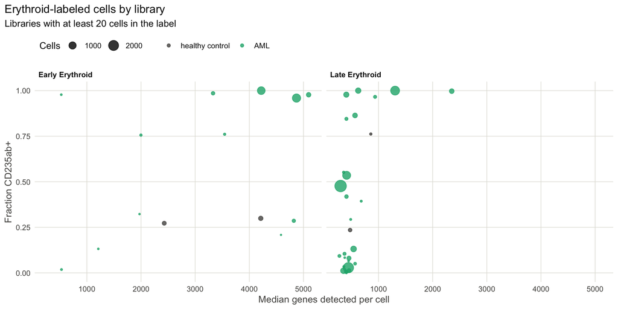

```r
erythroid_summary |>
  filter(n_cells >= 20) |>
  ggplot(aes(x = median_genes_detected, y = frac_CD235ab_pos, size = n_cells, color = role)) +
  geom_point(alpha = 0.8) +
  facet_wrap(~bmm_label_broad) +
  scale_color_manual(values = c(`healthy control` = ink_secondary, AML = "#1baf7a"), name = NULL) +
  scale_size_area(max_size = 6, name = "Cells") +
  scale_y_continuous(limits = c(0, 1)) +
  labs(x = "Median genes detected per cell", y = "Fraction CD235ab+",
       title = "Erythroid-labeled cells by library",
       subtitle = "Libraries with at least 20 cells in the label")
```

Within late erythroid calls, how do CD235ab-negative cells compare with CD235ab-positive ones?

```r
cells |>
  filter(bmm_label_broad == "Late Erythroid") |>
  group_by(role, CD235ab = if_else(pos_CD235ab, "CD235ab+", "CD235ab-")) |>
  summarize(
    n_cells = n(),
    median_genes_detected = median(detected),
    median_umis = median(sum),
    median_mapping_error = median(bmm_mapping_error),
    frac_qc_fail = mean(!qc_pass),
    frac_HBB_detected = mean(rna_HBB > 0),
    median_knn_prob = median(bmm_label_prob),
    .groups = "drop"
  ) |>
  knitr::kable(digits = 2)
```

| role | CD235ab | n_cells | median_genes_detected | median_umis | median_mapping_error | frac_qc_fail | frac_HBB_detected | median_knn_prob |
| --- | --- | --- | --- | --- | --- | --- | --- | --- |
| healthy control | CD235ab+ | 115 | 1283.0 | 5482.0 | 8.19 | 0.23 | 0.90 | 0.93 |
| healthy control | CD235ab- | 186 | 432.5 | 802.0 | 16.32 | 0.55 | 0.63 | 0.83 |
| healthy control | NA | 7 | 392.0 | 649.0 | 18.41 | 0.71 | 0.57 | 0.93 |
| AML | CD235ab+ | 5826 | 463.5 | 1077.5 | 14.13 | 0.36 | 0.59 | 1.00 |
| AML | CD235ab- | 6735 | 397.0 | 766.0 | 16.52 | 0.59 | 0.18 | 1.00 |
| AML | NA | 253 | 504.0 | 1197.0 | 14.03 | 0.31 | 0.53 | 0.97 |

What ScPCA’s consensus calls the CD235ab-negative late erythroid cells, top labels:

```r
cells |>
  filter(bmm_label_broad == "Late Erythroid", !pos_CD235ab) |>
  count(consensus_celltype_annotation, sort = TRUE) |>
  mutate(share = n / sum(n)) |>
  head(10) |>
  knitr::kable(digits = 3)
```

| consensus_celltype_annotation | n | share |
| --- | --- | --- |
| hematopoietic precursor cell | 3834 | 0.554 |
| Unknown | 2461 | 0.356 |
| monocyte | 231 | 0.033 |
| myeloid leukocyte | 133 | 0.019 |
| erythroid lineage cell | 82 | 0.012 |
| hematopoietic stem cell | 78 | 0.011 |
| erythrocyte | 21 | 0.003 |
| erythroid progenitor cell | 19 | 0.003 |
| B cell | 7 | 0.001 |
| natural killer cell | 7 | 0.001 |

## Protein by label

Mean ADT value (color, scaled per target across both panels) and fraction positive (size) for each BoneMarrowMap fine label, in the healthy controls and in AML. Cells passing QC, singlets, labels with at least 20 such cells in a panel.

```r
adt_long <- cells |>
  filter(qc_pass, singlet) |>
  select(role, bmm_label, starts_with("adt_"), starts_with("pos_")) |>
  select(-any_of("adt_scpca_filter")) |>
  tidyr::pivot_longer(
    -c(role, bmm_label),
    names_to = c(".value", "target"),
    names_pattern = "^(adt|pos)_(.+)$"
  )

adt_dot <- adt_long |>
  group_by(role, bmm_label, target) |>
  summarize(n_cells = n(), mean_adt = mean(adt, na.rm = TRUE), frac_pos = mean(pos, na.rm = TRUE),
            .groups = "drop") |>
  filter(n_cells >= 20) |>
  group_by(target) |>
  mutate(scaled = (mean_adt - min(mean_adt)) / (max(mean_adt) - min(mean_adt))) |>
  ungroup() |>
  mutate(
    bmm_label = factor(bmm_label, levels = rev(fine_levels)),
    target = factor(target, levels = c(
      "CD90", "CD49f", "CD133", "CD45RA", "CD123", "CD366", "CD33", "CD7",
      "CD36", "CD32", "CD71", "CD235ab", "CD10", "CD19", "CD3", "CD25", "CD127", "CD152",
      "CD279", "CD274", "CD45"
    ))
  )
stopifnot(!anyNA(adt_dot$target))
```

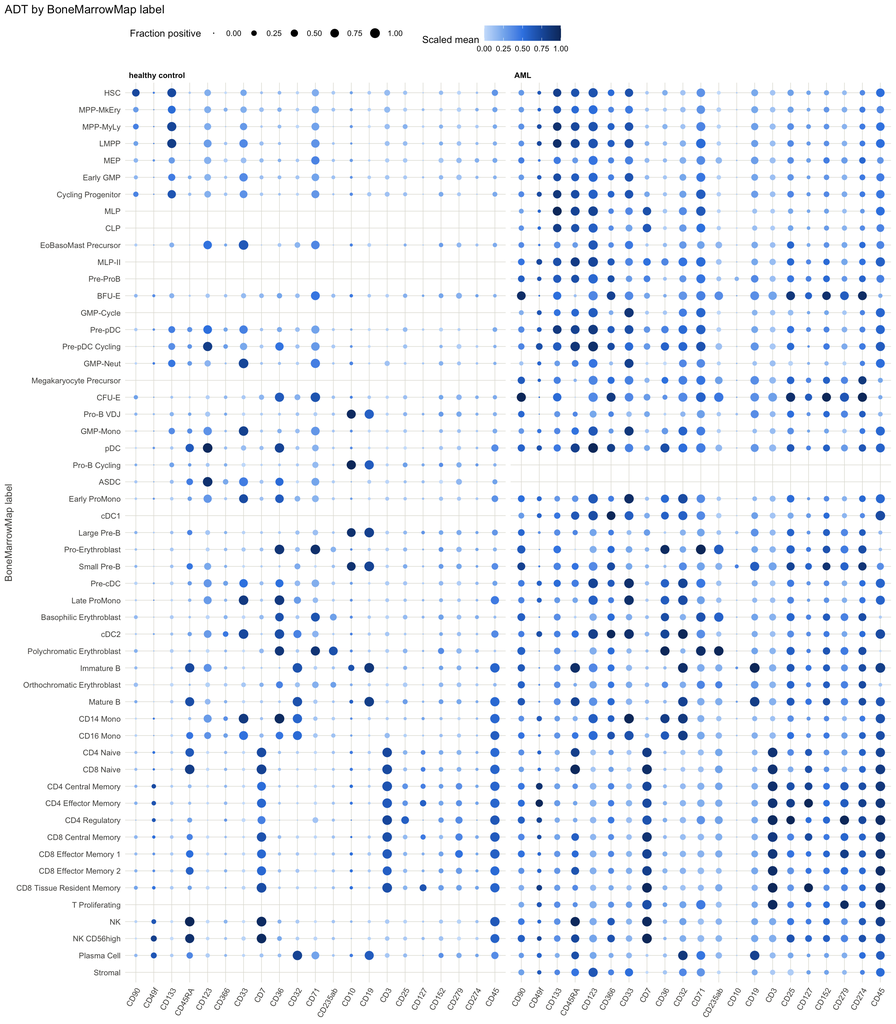

```r
ggplot(adt_dot, aes(x = target, y = bmm_label, color = scaled, size = frac_pos)) +
  geom_point() +
  facet_wrap(~role) +
  scale_color_gradientn(colors = seq_blue, limits = c(0, 1), name = "Scaled mean") +
  scale_size_area(max_size = 4.5, limits = c(0, 1), name = "Fraction positive") +
  labs(x = NULL, y = "BoneMarrowMap label", title = "ADT by BoneMarrowMap label") +
  theme(axis.text.x = element_text(angle = 60, hjust = 1))
```

### HSPC state

Inside the HSPC compartment, the expected pattern in normal marrow is HSC/MPP CD90+ CD49f+ CD45RA−, with CD45RA gained in LMPP/MLP and GMP. Distributions per label, healthy controls vs AML, for the HSPC targets and the LSC-associated targets (CD123, TIM-3/CD366).

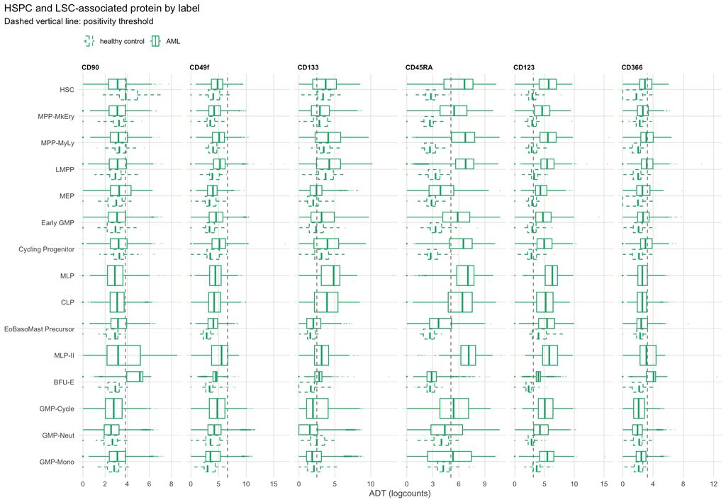

```r
hspc_labels <- c("HSC", "MPP-MkEry", "MPP-MyLy", "LMPP", "MLP", "MLP-II", "CLP",
                 "Cycling Progenitor", "Early GMP", "GMP-Cycle", "GMP-Neut", "GMP-Mono",
                 "MEP", "BFU-E", "EoBasoMast Precursor")

hspc_long <- adt_long |>
  filter(bmm_label %in% hspc_labels, target %in% c("CD90", "CD49f", "CD133", "CD45RA", "CD123",
                                                   "CD366")) |>
  add_count(role, bmm_label, target, name = "n_label") |>
  filter(n_label >= 20) |>
  mutate(
    bmm_label = factor(bmm_label, levels = rev(intersect(fine_levels, hspc_labels))),
    target = factor(target, levels = c("CD90", "CD49f", "CD133", "CD45RA", "CD123", "CD366"))
  )

ggplot(hspc_long, aes(x = adt, y = bmm_label, linetype = role)) +
  geom_boxplot(color = "#1baf7a", fill = NA, outlier.size = 0.2, outlier.alpha = 0.2,
               position = position_dodge(width = 0.8)) +
  geom_vline(
    data = adt_thresholds |> filter(target %in% levels(hspc_long$target)) |>
      mutate(target = factor(target, levels = levels(hspc_long$target))),
    aes(xintercept = threshold), linetype = "dashed", color = ink_muted
  ) +
  facet_wrap(~target, scales = "free_x", nrow = 1) +
  scale_linetype_manual(values = c(`healthy control` = "dashed", AML = "solid"), name = NULL) +
  labs(x = "ADT (logcounts)", y = NULL, title = "HSPC and LSC-associated protein by label",
       subtitle = "Dashed vertical line: positivity threshold")
```

```r
adt_long |>
  filter(bmm_label %in% hspc_labels, target %in% c("CD90", "CD49f", "CD133", "CD45RA", "CD123",
                                                   "CD366")) |>
  group_by(role, bmm_label, target) |>
  summarize(n_cells = n(), frac_pos = mean(pos, na.rm = TRUE), .groups = "drop") |>
  filter(n_cells >= 20) |>
  tidyr::pivot_wider(names_from = target, values_from = frac_pos) |>
  mutate(bmm_label = factor(bmm_label, levels = intersect(fine_levels, hspc_labels))) |>
  arrange(role, bmm_label) |>
  knitr::kable(digits = 2)
```

| role | bmm_label | n_cells | CD123 | CD133 | CD366 | CD45RA | CD49f | CD90 |
| --- | --- | --- | --- | --- | --- | --- | --- | --- |
| healthy control | HSC | 108 | 0.40 | 0.80 | 0.03 | 0.02 | 0.01 | 0.55 |
| healthy control | MPP-MkEry | 57 | 0.44 | 0.60 | 0.11 | 0.02 | 0.00 | 0.25 |
| healthy control | MPP-MyLy | 44 | 0.45 | 0.86 | 0.00 | 0.00 | 0.00 | 0.27 |
| healthy control | LMPP | 64 | 0.61 | 0.84 | 0.06 | 0.00 | 0.00 | 0.17 |
| healthy control | MEP | 56 | 0.49 | 0.35 | 0.11 | 0.00 | 0.02 | 0.15 |
| healthy control | Early GMP | 154 | 0.41 | 0.48 | 0.05 | 0.09 | 0.00 | 0.11 |
| healthy control | Cycling Progenitor | 71 | 0.41 | 0.69 | 0.07 | 0.06 | 0.00 | 0.23 |
| healthy control | EoBasoMast Precursor | 22 | 0.73 | 0.18 | 0.05 | 0.00 | 0.00 | 0.05 |
| healthy control | BFU-E | 92 | 0.13 | 0.20 | 0.07 | 0.01 | 0.04 | 0.08 |
| healthy control | GMP-Neut | 88 | 0.36 | 0.51 | 0.01 | 0.16 | 0.02 | 0.02 |
| healthy control | GMP-Mono | 121 | 0.71 | 0.36 | 0.03 | 0.21 | 0.00 | 0.03 |
| AML | HSC | 1062 | 0.87 | 0.66 | 0.40 | 0.68 | 0.09 | 0.27 |
| AML | MPP-MkEry | 2857 | 0.78 | 0.58 | 0.29 | 0.54 | 0.07 | 0.25 |
| AML | MPP-MyLy | 2837 | 0.89 | 0.71 | 0.45 | 0.75 | 0.16 | 0.31 |
| AML | LMPP | 11681 | 0.93 | 0.74 | 0.47 | 0.82 | 0.18 | 0.28 |
| AML | MEP | 2567 | 0.82 | 0.49 | 0.32 | 0.29 | 0.03 | 0.33 |
| AML | Early GMP | 21717 | 0.83 | 0.60 | 0.31 | 0.61 | 0.14 | 0.26 |
| AML | Cycling Progenitor | 3502 | 0.86 | 0.70 | 0.41 | 0.73 | 0.19 | 0.29 |
| AML | MLP | 1537 | 0.95 | 0.81 | 0.25 | 0.81 | 0.06 | 0.18 |
| AML | CLP | 2076 | 0.85 | 0.70 | 0.22 | 0.67 | 0.07 | 0.23 |
| AML | EoBasoMast Precursor | 2919 | 0.89 | 0.39 | 0.25 | 0.26 | 0.02 | 0.28 |
| AML | MLP-II | 276 | 0.98 | 0.69 | 0.48 | 0.85 | 0.29 | 0.41 |
| AML | BFU-E | 2627 | 0.86 | 0.65 | 0.73 | 0.04 | 0.00 | 0.77 |
| AML | GMP-Cycle | 1168 | 0.88 | 0.42 | 0.16 | 0.57 | 0.18 | 0.18 |
| AML | GMP-Neut | 9181 | 0.76 | 0.26 | 0.10 | 0.42 | 0.11 | 0.12 |
| AML | GMP-Mono | 7035 | 0.88 | 0.34 | 0.20 | 0.52 | 0.13 | 0.26 |

## RNA markers by label

Mean log-normalized expression (color, scaled per gene across both panels) and fraction of cells with any expression (size), by BoneMarrowMap broad label. Cells passing QC, singlets, labels with at least 20 such cells in a panel.

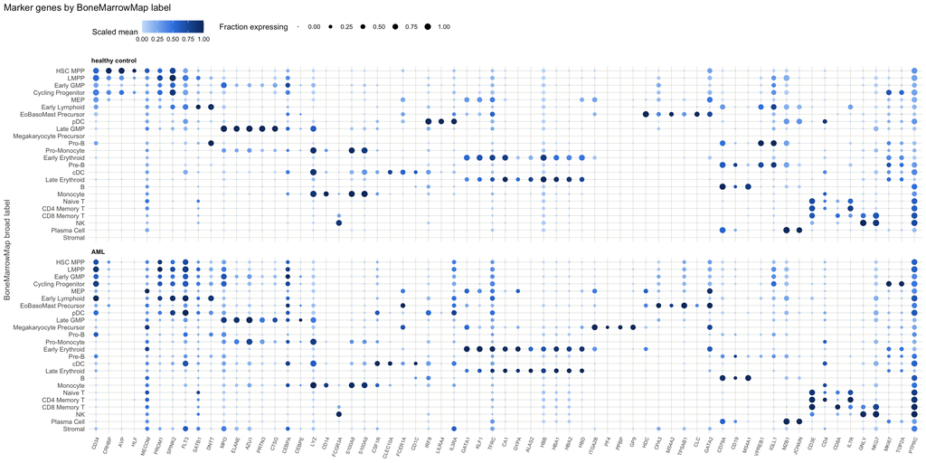

```r
rna_dot <- cells |>
  filter(qc_pass, singlet) |>
  select(role, bmm_label_broad, starts_with("rna_")) |>
  tidyr::pivot_longer(starts_with("rna_"), names_to = "gene", names_prefix = "rna_",
                      values_to = "expr") |>
  group_by(role, bmm_label_broad, gene) |>
  summarize(n_cells = n(), mean_expr = mean(expr), frac_expr = mean(expr > 0), .groups = "drop") |>
  filter(n_cells >= 20) |>
  group_by(gene) |>
  mutate(scaled = mean_expr / max(mean_expr)) |>
  ungroup() |>
  mutate(
    bmm_label_broad = factor(bmm_label_broad, levels = rev(broad_levels)),
    gene = factor(gene, levels = rna_genes)
  )

ggplot(rna_dot, aes(x = gene, y = bmm_label_broad, color = scaled, size = frac_expr)) +
  geom_point() +
  facet_wrap(~role, ncol = 1) +
  scale_color_gradientn(colors = seq_blue, limits = c(0, 1), name = "Scaled mean") +
  scale_size_area(max_size = 3.5, limits = c(0, 1), name = "Fraction expressing") +
  labs(x = NULL, y = "BoneMarrowMap broad label", title = "Marker genes by BoneMarrowMap label") +
  theme(axis.text.x = element_text(angle = 70, hjust = 1, size = 7))
```

EoBasoMast calls need basophil/mast genes (`HDC`, `CPA3`, `MS4A2`), not just tryptase (`bonemarrowmap.md`, step 5):

```r
cells |>
  filter(bmm_label_broad == "EoBasoMast Precursor") |>
  group_by(role) |>
  summarize(
    n_cells = n(),
    across(c(rna_HDC, rna_CPA3, rna_MS4A2, rna_CLC, rna_TPSAB1, rna_CD34), \(x) mean(x > 0))
  ) |>
  knitr::kable(digits = 2)
```

| role | n_cells | rna_HDC | rna_CPA3 | rna_MS4A2 | rna_CLC | rna_TPSAB1 | rna_CD34 |
| --- | --- | --- | --- | --- | --- | --- | --- |
| healthy control | 24 | 0.92 | 0.42 | 0.46 | 0.58 | 0.42 | 0.33 |
| AML | 3234 | 0.34 | 0.58 | 0.28 | 0.22 | 0.83 | 0.25 |

## Comparison with ScPCA’s consensus labels

Rows are BoneMarrowMap broad labels, normalized to sum to 1. Columns are ScPCA’s consensus labels (the 15 most common; the rest pooled as “other”). All cells.

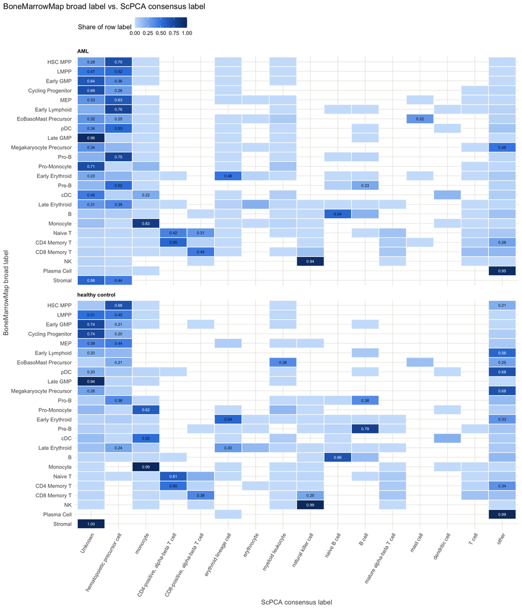

```r
top_consensus <- cells |>
  count(consensus_celltype_annotation, sort = TRUE) |>
  head(15) |>
  pull(consensus_celltype_annotation)

consensus_df <- cells |>
  transmute(
    assay = as.character(role),
    row = bmm_label_broad,
    col = if_else(consensus_celltype_annotation %in% top_consensus,
                  consensus_celltype_annotation, "other")
  )

plot_crosstab(
  consensus_df,
  title = "BoneMarrowMap broad label vs. ScPCA consensus label",
  row_title = "BoneMarrowMap broad label",
  col_title = "ScPCA consensus label",
  row_levels = broad_levels,
  col_levels = c(top_consensus, "other")
)
```

## Composition by library

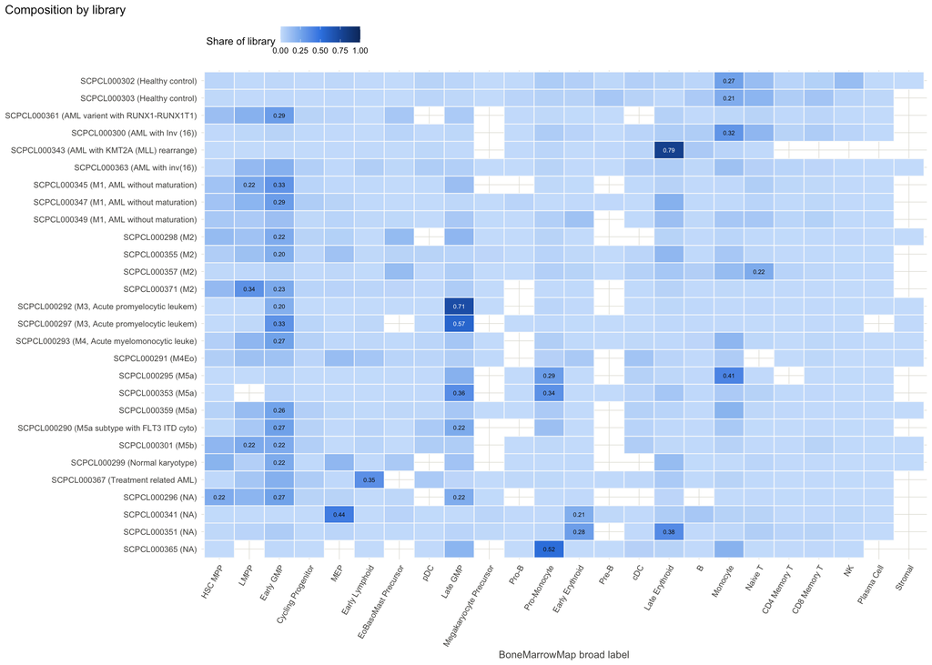

```r
composition <- cells |>
  count(role, library_id, subdiagnosis, bmm_label_broad) |>
  group_by(library_id) |>
  mutate(share = n / sum(n)) |>
  ungroup()

library_order <- cells |>
  distinct(role, library_id, subdiagnosis) |>
  arrange(role, subdiagnosis, library_id) |>
  mutate(label = paste0(library_id, " (", substr(subdiagnosis, 1, 30), ")"))

qc_by_library <- cells |>
  group_by(library_id) |>
  summarize(frac_qc_fail = mean(!qc_pass))

composition |>
  left_join(library_order |> select(library_id, label), by = "library_id") |>
  mutate(
    label = factor(label, levels = rev(library_order$label)),
    bmm_label_broad = factor(bmm_label_broad, levels = broad_levels)
  ) |>
  ggplot(aes(x = bmm_label_broad, y = label, fill = share)) +
  geom_tile(color = "#fcfcfb", linewidth = 0.4) +
  geom_text(aes(label = ifelse(share >= 0.2, sprintf("%.2f", share), ""), color = share > 0.55),
            size = 2.3, show.legend = FALSE) +
  scale_fill_gradientn(colors = seq_blue, limits = c(0, 1), name = "Share of library") +
  scale_color_manual(values = c(`FALSE` = ink_primary, `TRUE` = "#ffffff")) +
  labs(x = "BoneMarrowMap broad label", y = NULL, title = "Composition by library") +
  theme(axis.text.x = element_text(angle = 60, hjust = 1), panel.grid = element_blank())
```

```r
cells |>
  group_by(role, library_id, subdiagnosis) |>
  summarize(
    n_cells = n(),
    median_mapping_error = median(bmm_mapping_error),
    frac_qc_fail = mean(!qc_pass),
    median_genes_detected = median(detected),
    .groups = "drop"
  ) |>
  arrange(desc(median_mapping_error)) |>
  knitr::kable(digits = 3)
```

| role | library_id | subdiagnosis | n_cells | median_mapping_error | frac_qc_fail | median_genes_detected |
| --- | --- | --- | --- | --- | --- | --- |
| AML | SCPCL000343 | AML with KMT2A (MLL) rearranged | 3416 | 17.354 | 0.661 | 323.0 |
| AML | SCPCL000299 | Normal karyotype | 1640 | 12.486 | 0.123 | 1537.0 |
| AML | SCPCL000341 | NA | 6366 | 11.826 | 0.068 | 3534.0 |
| AML | SCPCL000347 | M1, AML without maturation | 10895 | 11.720 | 0.114 | 921.0 |
| AML | SCPCL000298 | M2 | 5284 | 11.150 | 0.025 | 2580.5 |
| AML | SCPCL000361 | AML varient with RUNX1-RUNX1T1 fusion | 3627 | 11.139 | 0.062 | 4036.0 |
| AML | SCPCL000371 | M2 | 3187 | 11.095 | 0.041 | 4332.0 |
| AML | SCPCL000365 | NA | 4854 | 11.076 | 0.087 | 1168.0 |
| AML | SCPCL000301 | M5b | 5395 | 10.651 | 0.036 | 3593.0 |
| AML | SCPCL000292 | M3, Acute promyelocytic leukemia | 7429 | 10.483 | 0.051 | 814.0 |
| AML | SCPCL000297 | M3, Acute promyelocytic leukemia | 4026 | 10.308 | 0.014 | 2416.5 |
| AML | SCPCL000355 | M2 | 7702 | 10.223 | 0.082 | 1147.5 |
| AML | SCPCL000293 | M4, Acute myelomonocytic leukemia | 4403 | 10.105 | 0.049 | 3370.0 |
| AML | SCPCL000291 | M4Eo | 2450 | 9.891 | 0.016 | 2849.0 |
| AML | SCPCL000357 | M2 | 5890 | 9.751 | 0.064 | 1676.0 |
| AML | SCPCL000359 | M5a | 10553 | 9.648 | 0.022 | 2162.0 |
| AML | SCPCL000363 | AML with inv(16) | 7983 | 9.615 | 0.045 | 3766.0 |
| AML | SCPCL000353 | M5a | 6327 | 9.541 | 0.087 | 876.0 |
| AML | SCPCL000349 | M1, AML without maturation | 3172 | 9.452 | 0.038 | 2406.0 |
| AML | SCPCL000345 | M1, AML without maturation | 5829 | 8.910 | 0.022 | 2782.0 |
| healthy control | SCPCL000302 | Healthy control | 5650 | 8.825 | 0.057 | 1267.0 |
| AML | SCPCL000295 | M5a | 5443 | 8.823 | 0.015 | 1432.0 |
| AML | SCPCL000290 | M5a subtype with FLT3 ITD cytogenetics, CNS1 | 4635 | 8.822 | 0.022 | 3071.0 |
| AML | SCPCL000300 | AML with Inv (16) | 2522 | 8.480 | 0.033 | 1541.0 |
| AML | SCPCL000296 | NA | 3546 | 8.473 | 0.012 | 3112.5 |
| AML | SCPCL000367 | Treatment related AML | 8199 | 8.434 | 0.035 | 2723.0 |
| AML | SCPCL000351 | NA | 4164 | 8.269 | 0.018 | 1786.0 |
| healthy control | SCPCL000303 | Healthy control | 9082 | 7.984 | 0.041 | 1122.0 |

## Mapping error and transcriptional complexity

Is mapping error related to how many genes a cell expresses? Spearman correlation by broad label, healthy controls vs AML (labels with at least 50 cells).

```r
cells |>
  group_by(role, bmm_label_broad) |>
  filter(n() >= 50) |>
  summarize(
    n_cells = n(),
    median_genes_detected = median(detected),
    median_mapping_error = median(bmm_mapping_error),
    spearman_error_vs_detected = cor(bmm_mapping_error, detected, method = "spearman"),
    .groups = "drop"
  ) |>
  arrange(bmm_label_broad, role) |>
  knitr::kable(digits = 2)
```

| role | bmm_label_broad | n_cells | median_genes_detected | median_mapping_error | spearman_error_vs_detected |
| --- | --- | --- | --- | --- | --- |
| healthy control | B | 770 | 975.0 | 8.08 | 0.27 |
| AML | B | 2210 | 1288.5 | 9.19 | -0.11 |
| healthy control | CD4 Memory T | 732 | 1108.0 | 8.05 | 0.00 |
| AML | CD4 Memory T | 1235 | 1607.0 | 8.84 | 0.07 |
| healthy control | CD8 Memory T | 1174 | 976.5 | 8.31 | 0.15 |
| AML | CD8 Memory T | 1815 | 1501.0 | 9.17 | 0.26 |
| healthy control | Cycling Progenitor | 80 | 3602.0 | 8.18 | -0.09 |
| AML | Cycling Progenitor | 3979 | 4696.0 | 9.55 | -0.07 |
| healthy control | Early Erythroid | 619 | 3947.0 | 8.10 | -0.45 |
| AML | Early Erythroid | 3716 | 4346.5 | 11.25 | -0.11 |
| healthy control | Early GMP | 181 | 2425.0 | 8.23 | -0.53 |
| AML | Early GMP | 24861 | 3036.0 | 9.89 | -0.16 |
| healthy control | Early Lymphoid | 70 | 2225.0 | 7.92 | -0.22 |
| AML | Early Lymphoid | 4456 | 3180.0 | 8.48 | -0.08 |
| AML | EoBasoMast Precursor | 3234 | 2041.0 | 11.63 | 0.17 |
| healthy control | HSC MPP | 233 | 2422.0 | 7.90 | -0.13 |
| AML | HSC MPP | 7473 | 2729.0 | 11.18 | 0.17 |
| healthy control | LMPP | 75 | 3133.0 | 7.27 | -0.03 |
| AML | LMPP | 13817 | 3759.0 | 10.43 | 0.16 |
| healthy control | Late Erythroid | 308 | 497.0 | 15.14 | -0.32 |
| AML | Late Erythroid | 12814 | 419.0 | 15.81 | -0.44 |
| healthy control | Late GMP | 258 | 1427.0 | 7.20 | -0.17 |
| AML | Late GMP | 19444 | 1314.0 | 9.42 | -0.01 |
| healthy control | MEP | 177 | 2948.0 | 8.52 | -0.27 |
| AML | MEP | 5996 | 2897.0 | 11.41 | 0.07 |
| AML | Megakaryocyte Precursor | 385 | 2769.0 | 9.95 | 0.08 |
| healthy control | Monocyte | 3466 | 1069.5 | 8.53 | -0.02 |
| AML | Monocyte | 11640 | 1663.0 | 9.71 | 0.16 |
| healthy control | NK | 1046 | 1365.0 | 8.90 | 0.22 |
| AML | NK | 689 | 1642.0 | 9.60 | 0.30 |
| healthy control | Naive T | 2353 | 1033.0 | 7.65 | -0.09 |
| AML | Naive T | 4477 | 1236.0 | 8.28 | -0.06 |
| healthy control | Plasma Cell | 168 | 2475.5 | 7.10 | 0.15 |
| AML | Plasma Cell | 194 | 2447.5 | 8.19 | -0.25 |
| healthy control | Pre-B | 918 | 1546.5 | 7.77 | 0.01 |
| AML | Pre-B | 277 | 843.0 | 11.15 | -0.39 |
| healthy control | Pro-B | 284 | 1416.0 | 8.06 | -0.07 |
| AML | Pro-B | 513 | 748.0 | 11.63 | 0.21 |
| healthy control | Pro-Monocyte | 784 | 689.0 | 9.15 | -0.34 |
| AML | Pro-Monocyte | 9947 | 1171.0 | 9.55 | -0.17 |
| healthy control | cDC | 620 | 2442.0 | 8.68 | -0.35 |
| AML | cDC | 3053 | 3199.0 | 10.32 | 0.08 |
| healthy control | pDC | 372 | 1986.0 | 8.26 | -0.18 |
| AML | pDC | 2680 | 3447.0 | 9.41 | 0.00 |